# Clase Práctica 1: Confiabilidad de estructuras multidimensionales

HENC

2023-10-03

```r
library(MplusAutomation)
library(data.table)
library(dplyr)
```

```r
D<-fread("Sim_data_2_1.dat")
```

# Modelo 1

El primer modelo que vamos a estimar es un modelo jerárquico (h) de cuatro dimensiones (f1, f2, f3 y f4). Es decir, la variable latente explica la variabilidad de las cuatro dimensiones y estas en turno explican la de las indicaciones. Esto modelo se puede estimar facilmente con la función `sem()` del paquete `lavaan`.

Un problema es que el resultado no es de fiar “the optimizer warns that a solution has NOT been found!”. Esto significa que el modelo está pobremente especificado y tendremos que hacer cambios (en los confines del modelo teórico) para poder obtener resultados.

```r
library(lavaan)

mod.1<-'f1 =~ V1 + V2 + V3 + V4 + V5
        f2 =~ V6 + V7 + V8 + V9
        f3 =~ V10 + V11 + V12
        f4 =~ V13 + V14 + V15
        h =~ f1 + f2 + f3 + f4'

r.mod.1<-sem(mod.1, data=D, ordered=T)
```

```
## Warning in lavaan::lavaan(model = mod.1, data = D, ordered = T, model.type = "sem", : lavaan WARNING:
##     the optimizer warns that a solution has NOT been found!
```

## Mejoramos la estimacion

Una forma usual de mejorar la optimización consiste en brindar información útil como por ejemplo la escala de las varianzas de la variable latente. Esto se hace con la instrucción `h ~~ 1*h`. Esto significa que la varianza del factor de alto orden es igual a 1. Hacemos lo mismo para el resto de los factores.

El modelo se estimó pero con problemas. En este caso se halló una solución pero a costa de que algunas covarianzas o varianzas son negativas. Lo cual tendría poco sentido. Esto es síntoma, generalmente, de que hay por lo menos una variable muy problemática.

```r
mod.1<-'f1 =~ V1 + V2 + V3 + V4 + V5
        f2 =~ V6 + V7 + V8 + V9
        f3 =~ V10 + V11 + V12
        f4 =~ V13 + V14 + V15
        h =~ f1 + f2 + f3 + f4
        h ~~ 1*h
        f1 ~~ 1*f1
        f2 ~~ 1*f2
        f3 ~~ 1*f3
        f4 ~~ 1*f4'

r.mod.1<-cfa(mod.1, data=D, ordered=T)
```

## Extraemos resultados

```r
summary(r.mod.1, fit.measures=TRUE)
```

```
## lavaan 0.6.16 ended normally after 40 iterations
##
##   Estimator                                       DWLS
##   Optimization method                           NLMINB
##   Number of model parameters                        29
##
##   Number of observations                         10000
##
## Model Test User Model:
##                                                 Standard      Scaled
##   Test Statistic                              130410.012   78406.185
##   Degrees of freedom                                  91          91
##   P-value (Chi-square)                             0.000       0.000
##   Scaling correction factor                                    1.664
##   Shift parameter                                             50.040
##     simple second-order correction
##
## Model Test Baseline Model:
##
##   Test statistic                           1216512.106  492948.060
##   Degrees of freedom                               105         105
##   P-value                                        0.000       0.000
##   Scaling correction factor                                  2.468
##
## User Model versus Baseline Model:
##
##   Comparative Fit Index (CFI)                    0.893       0.841
##   Tucker-Lewis Index (TLI)                       0.876       0.817
##
##   Robust Comparative Fit Index (CFI)                           NaN
##   Robust Tucker-Lewis Index (TLI)                             -Inf
##
## Root Mean Square Error of Approximation:
##
##   RMSEA                                          0.378       0.293
##   90 Percent confidence interval - lower         0.377       0.292
##   90 Percent confidence interval - upper         0.380       0.295
##   P-value H_0: RMSEA <= 0.050                    0.000       0.000
##   P-value H_0: RMSEA >= 0.080                    1.000       1.000
##
```

[output cut: 109 more lines]

```
##     V1                1.000
##     V2                1.000
##     V3                1.000
##     V4                1.000
##     V5                1.000
##     V6                1.000
##     V7                1.000
##     V8                1.000
##     V9                1.000
##     V10               1.000
##     V11               1.000
##     V12               1.000
##     V13               1.000
##     V14               1.000
##     V15               1.000
```

```r
fitMeasures(r.mod.1, c("cfi.robust","tli.robust","rmsea.robust"))
```

```
##   cfi.robust   tli.robust rmsea.robust
##          NaN         -Inf          Inf
```

Confirmamos que el modelo tiene un ajuste muy pobre.

```r
fitMeasures(r.mod.1, c("cfi.scaled","tli.scaled","rmsea.scaled"))
```

```
##   cfi.scaled   tli.scaled rmsea.scaled
##        0.841        0.817        0.293
```

Al revisar las cargas factoriales notamos que V9 y V8 tienen un comportamiento muy deficiente puesto que tienen mucho error. Esto es señal de que la dimensión a la que pertenecen está pobremente especificada.

```r
inspect(r.mod.1,what="std")
```

```
## $lambda
##        f1     f2    f3    f4 h
## V1  1.414  0.000 0.000 0.000 0
## V2  0.950  0.000 0.000 0.000 0
## V3  0.926  0.000 0.000 0.000 0
## V4  0.948  0.000 0.000 0.000 0
## V5  0.888  0.000 0.000 0.000 0
## V6  0.000  1.000 0.000 0.000 0
## V7  0.000  0.144 0.000 0.000 0
## V8  0.000  0.081 0.000 0.000 0
## V9  0.000 -0.018 0.000 0.000 0
## V10 0.000  0.000 1.449 0.000 0
## V11 0.000  0.000 0.842 0.000 0
## V12 0.000  0.000 0.911 0.000 0
## V13 0.000  0.000 0.000 1.430 0
## V14 0.000  0.000 0.000 0.833 0
## V15 0.000  0.000 0.000 0.900 0
##
## $theta
##         V1     V2     V3     V4     V5     V6     V7     V8     V9    V10
## V1  -1.000
## V2   0.000  0.098
## V3   0.000  0.000  0.143
## V4   0.000  0.000  0.000  0.101
## V5   0.000  0.000  0.000  0.000  0.211
## V6   0.000  0.000  0.000  0.000  0.000  0.000
## V7   0.000  0.000  0.000  0.000  0.000  0.000  0.979
## V8   0.000  0.000  0.000  0.000  0.000  0.000  0.000  0.993
## V9   0.000  0.000  0.000  0.000  0.000  0.000  0.000  0.000  1.000
## V10  0.000  0.000  0.000  0.000  0.000  0.000  0.000  0.000  0.000 -1.098
## V11  0.000  0.000  0.000  0.000  0.000  0.000  0.000  0.000  0.000  0.000
## V12  0.000  0.000  0.000  0.000  0.000  0.000  0.000  0.000  0.000  0.000
## V13  0.000  0.000  0.000  0.000  0.000  0.000  0.000  0.000  0.000  0.000
## V14  0.000  0.000  0.000  0.000  0.000  0.000  0.000  0.000  0.000  0.000
## V15  0.000  0.000  0.000  0.000  0.000  0.000  0.000  0.000  0.000  0.000
##        V11    V12    V13    V14    V15
## V1
## V2
## V3
## V4
```

[output cut: 74 more lines]

```
## V1       1
## V2       1
## V3       1
## V4       1
## V5       1
## V6       1
## V7       1
## V8       1
## V9       1
## V10      1
## V11      1
## V12      1
## V13      1
## V14      1
## V15      1
```

## Confiabilidad

No sería buena idea estimar confiabilidad con estos resultados. Pero para ejemplificar los cálculos lo haremos a continuación.

Para escalas multidimensionales tenemos dos opciones de funciones dentro de semTools: `reliabilityL2` y `compRelSEM`. La segunda opción corresponde a la función más actualizada y es la que se recomienda utilizar.

La confiabilidad total de la escala ($\omega_t$, omegaL1) es igual a .72 de acuerdo con `reliabilityL2`.

La confiabilidad total de las dimensiones atribuible al primer factor ($\omega_t$, omegaL2) es igual a .70 de acuerdo con `reliabilityL2`.

La confiabilidad total de la escala ($\omega_t$) es igual a .79 de acuerdo con `compRelSEM`. Este valor está ligeramente sobreestimado debido a problemas con la función.

La confiabilidad total de cada dimensión $i$ ($\omega_{t,i}$) se obtiene con la función `compRelSEM(r.mod.1)`.

La confiabilidad total del factor general (h) ($\omega_{h}$) se obtiene con la función `compRelSEM(r.mod.1, higher = "h", ord.scale = F)`. Es igual a .582.

```r
library(semTools)

reliabilityL2(r.mod.1, "h")
```

```
##        omegaL1        omegaL2 partialOmegaL1
##      0.7246639      0.7048951      0.9805787
```

```r
compRelSEM(r.mod.1, return.total = -1, ord.scale = F) # Reliability of the full scale
```

```
## total
## 0.792
```

```r
compRelSEM(r.mod.1) # Reliability of each dimension
```

```
##    f1    f2    f3    f4
## 0.865 0.198 0.862 0.837
```

```r
compRelSEM(r.mod.1, higher = "h", ord.scale = F) # Omega hierarchical is the true score variance in a composite that is attributable to the general factor
```

```
##    f1    f2    f3    f4     h
## 1.087 0.327 1.167 1.133 0.582
```

# Modelo 2

Ahora estimaremos una segunda propuesta de modelo de tres dimensiones (f1, f3 Y f4) con h como factor general.

```r
mod.2<-'f1 =~ V1 + V2 + V3 + V4 + V5
        f3 =~ V10 + V11 + V12
        f4 =~ V13 + V14 + V15
        h =~ f1 + f3 + f4'

r.mod.2<-cfa(mod.2, data=D, ordered=T)
```

# Extraemos resultados

Este modelo tiene muy buen ajuste cuando se consideran los estadísticos de ajuste global relativos.

```r
summary(r.mod.2, fit.measures=TRUE)
```

```
## lavaan 0.6.16 ended normally after 37 iterations
##
##   Estimator                                       DWLS
##   Optimization method                           NLMINB
##   Number of model parameters                        25
##
##   Number of observations                         10000
##
## Model Test User Model:
##                                               Standard      Scaled
##   Test Statistic                                16.243      44.041
##   Degrees of freedom                                41          41
##   P-value (Chi-square)                           1.000       0.344
##   Scaling correction factor                                  0.447
##   Shift parameter                                            7.685
##     simple second-order correction
##
## Model Test Baseline Model:
##
##   Test statistic                           1216426.580  460027.896
##   Degrees of freedom                                55          55
##   P-value                                        0.000       0.000
##   Scaling correction factor                                  2.644
##
## User Model versus Baseline Model:
##
##   Comparative Fit Index (CFI)                    1.000       1.000
##   Tucker-Lewis Index (TLI)                       1.000       1.000
##
##   Robust Comparative Fit Index (CFI)                         0.998
##   Robust Tucker-Lewis Index (TLI)                            0.998
##
## Root Mean Square Error of Approximation:
##
##   RMSEA                                          0.000       0.003
##   90 Percent confidence interval - lower         0.000       0.000
##   90 Percent confidence interval - upper         0.000       0.008
##   P-value H_0: RMSEA <= 0.050                    1.000       1.000
##   P-value H_0: RMSEA >= 0.080                    0.000       0.000
##
```

[output cut: 85 more lines]

```
##     h                 0.913    0.009  104.804    0.000
##
## Scales y*:
##                    Estimate  Std.Err  z-value  P(>|z|)
##     V1                1.000
##     V2                1.000
##     V3                1.000
##     V4                1.000
##     V5                1.000
##     V10               1.000
##     V11               1.000
##     V12               1.000
##     V13               1.000
##     V14               1.000
##     V15               1.000
```

```r
fitMeasures(r.mod.2, c("cfi.robust","tli.robust","rmsea.robust"))
```

```
##   cfi.robust   tli.robust rmsea.robust
##        0.998        0.998        0.032
```

## Confiabilidad

La confiabilidad total de la escala ($\omega_t$, omegaL1) es igual a .97 de acuerdo con `reliabilityL2`.

La confiabilidad total de las dimensiones atribuible al primer factor ($\omega_t$, omegaL2) es igual a .97 de acuerdo con `reliabilityL2`.

La confiabilidad total de la escala ($\omega_t$) es igual a .99 de acuerdo con `compRelSEM`. Este valor está ligeramente sobreestimado debido a problemas con la función.

La confiabilidad total del factor general (h) ($\omega_{h}$) se obtiene con la función `compRelSEM(r.mod.1, higher = "h", ord.scale = F)`. Es igual a .97.

```r
reliabilityL2(r.mod.2, "h")
```

```
##        omegaL1        omegaL2 partialOmegaL1
##      0.9741712      0.9782659      0.9963768
```

```r
compRelSEM(r.mod.2, return.total = TRUE, ord.scale = F) # Omega total> the total true score variance in a composite.
```

```
##    f1    f3    f4 total
## 0.992 0.988 0.991 0.997
```

```r
compRelSEM(r.mod.2, higher = "h", ord.scale = F) # Omega hierarchical is the true score variance in a composite that is attributable to the general factor
```

```
##    f1    f3    f4     h
## 0.992 0.988 0.991 0.974
```

# Diagramas

```r
#install.packages("devtools")
#devtools::install_github("alishinski/lavaanPlot")
library(lavaanPlot)

lavaanPlot(model = r.mod.2, node_options = list(shape = "box", fontname = "Helvetica"),
            edge_options = list(color = "red"), coefs = T,
            stand = TRUE, graph_options = list(rankdir = "LR"))
```

[interactive chart not shown]

# Scores observados vs scores factoriales

Al igual que en el caso unidimensional podemos producir los scores factoriales (scores óptimos dado el modelo) con la función `lavPredict`.

```r
p.mod.2<-data.frame(lavPredict(r.mod.2))
```

Si revisamos las primeras filas del objeto `p.mod.2`, nos daremos cuenta que se generaron cuatro nuevas variables. Estas contienen los scores de los tres factores y del factor general.

```r
head(p.mod.2)
```

```
##              f1            f3            f4        h
## 1 -4.331081e-15 -1.682694e-15 -3.229784e-18 0.000000
## 2  2.040271e+00  2.021451e+00  2.012129e+00 1.978809
## 3 -4.331081e-15 -1.682694e-15 -3.229784e-18 0.000000
## 4 -4.331081e-15 -1.682694e-15 -3.229784e-18 0.000000
## 5 -4.331081e-15 -1.682694e-15 -3.229784e-18 0.000000
## 6 -4.331081e-15 -1.682694e-15 -3.229784e-18 0.000000
```

Podemos graficar el score del factor general con el score del factor observado para ver su relación y grado de separación.

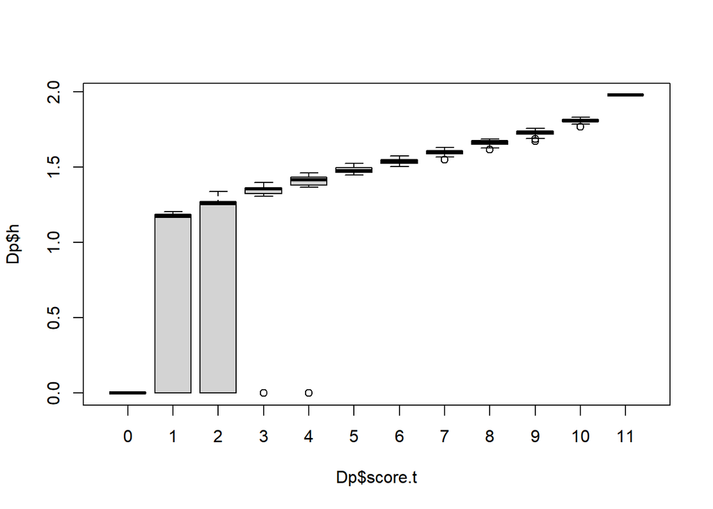

```r
Dp<-data.frame(cbind(D,p.mod.2))
Dp$score.t<-rowSums(D[,c(1:5,10:15)])

boxplot(Dp$h~Dp$score.t)
```

Podemos hacer lo mismo con la primera dimensión.

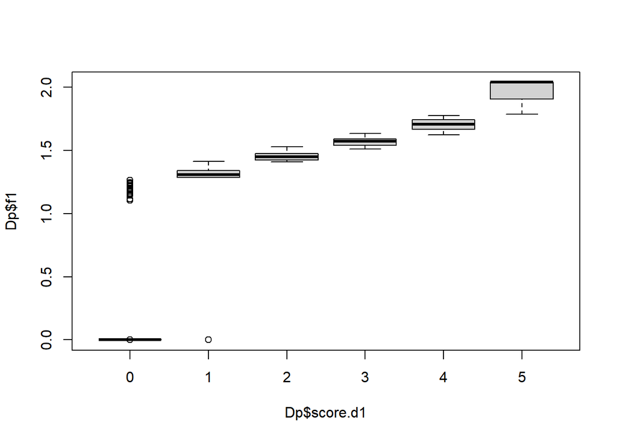

```r
Dp$score.d1<-rowSums(D[,c(1:5)])

boxplot(Dp$f1~Dp$score.d1)
```